# Report: act_report

The clean dataset was loaded into a pandas dataframe and the right datatypes set in preparation for exploration and analysis.

```python
import pandas as pd
twitter_archive_clean_df = pd.read_csv("twitter_archive_master.csv")
```

## Analysis and Visualizations

### Exploring the dataset

Data exploration is the first step of data analysis used to explore and visualize data to uncover insights from the start or identify areas or patterns to dig into more.

The cleaned dataframe was plotted on a scatter matrix to visualize possible correlation between features in the dataset. From the produced chart, we see that as expected, there is a high correlation between number of likes for a tweet and it's retweet count.

This however is not much to go on.

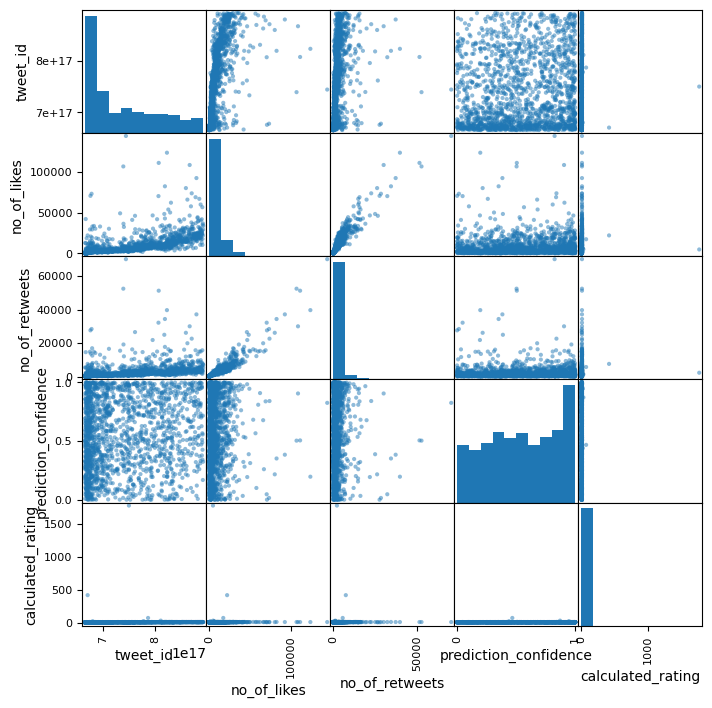

### Further analysis and exploration

#### 1. Tweets characteristics based on tweet source or platform

The relationship between the source of a tweet or it's mode of publication and the other feature in the dataset was also analysed.

The different tweeting platforms used by the handler within the period of study are:

- Using an iPhone (Twitter for iPhone)
- Using a web browser (Twitter Web CLient)
- TweetDeck - which is a platform that offers a more convenient Twitter experience by letting you view multiple timelines in one easy interface. It includes a host of advanced features to help get the most of Twitter: Manage multiple Twitter accounts, schedule Tweets for posting in the future, build Tweet collections, and more.

Descriptive statistics techniques were used explore the relationship between tweet source and the number of likes gotten. The results are shown in the table below.

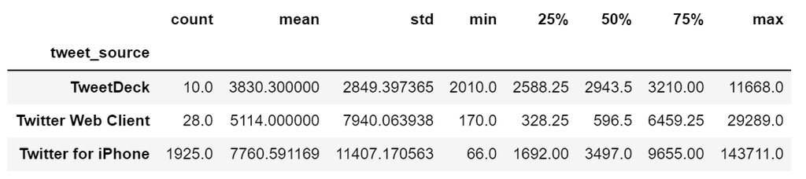

A chart was then used to communicate interesting insights from the table.

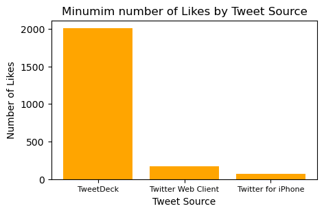

#### Insight:

We see clearly from the chart that the least number of likes a post got is far higher than of the other sources. This is expected as the TweetDeck platform provides tools that increase the reach of ones tweets.

#### 2. Tweets characteristics based on timestamp

It is import to look out for trends over time. For this reason, analysis was carried out on the relationships between the timestamp and other features (number of retweets, number of likes and average dog rating given).

The analysis carried out resulted in the following graphs.

From this line graph below, we see clearly that @WeRateDogs got it's highest number of retweets in December 2015.

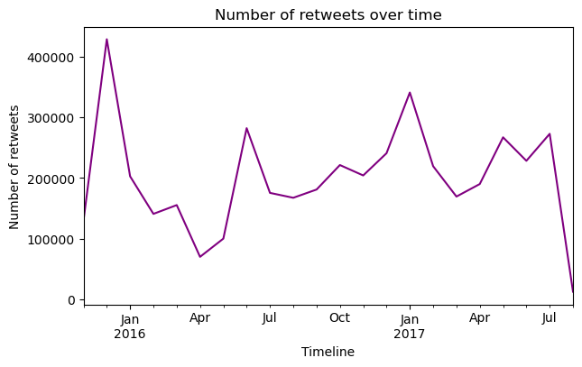

From the line graph below, we see clearly that @WeRateDogs got it's highest number of likes in July 2017.

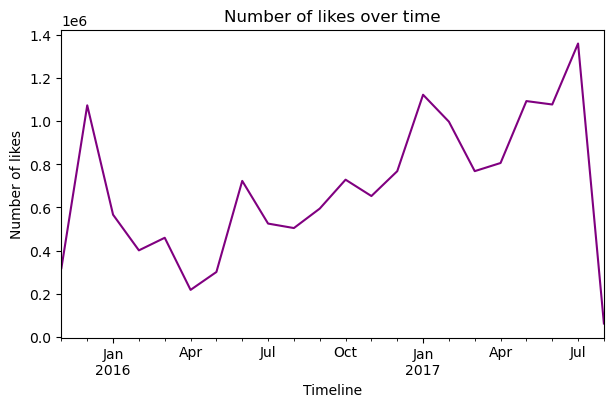

The line graph below shows that July 2016 had the highest average rating for the period of study.

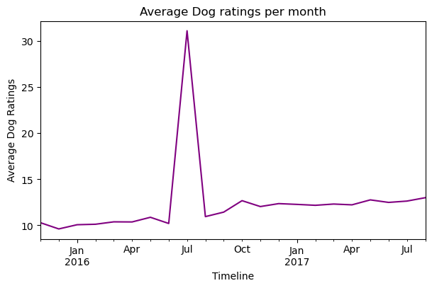

#### Insight:

We see clearly from the charts that Tweets made by @WeRateDogs in December, 2015 have the highest number of retweets while tweets made in July 2017 had the highest number of likes. July 2016 had the highest average dog ratings of the period considered. This seems interesing and would require further investigation (outside the scope of this project).

#### 3. Most loved dog traits based on rating given

In trying to understand the mind of the @WeRateDogs handler, I looked into possible trends in the ratings given to dogs. The key feature being the dog's characteristics as represented in the dog_traits column (doggo, floofer, pupper, puppo).

The comparison was done using a the ratio of the rating_numerator and rating_denominator columns. The results are shown below.

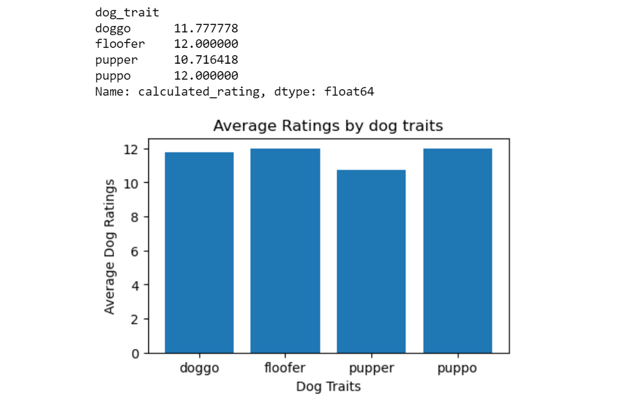

The chart above shows that averagely, dog considered to be of the puppo and floofer class are rated higher.

The images below show the dogs considered to be in the floofer and the puppo classes, respectively.

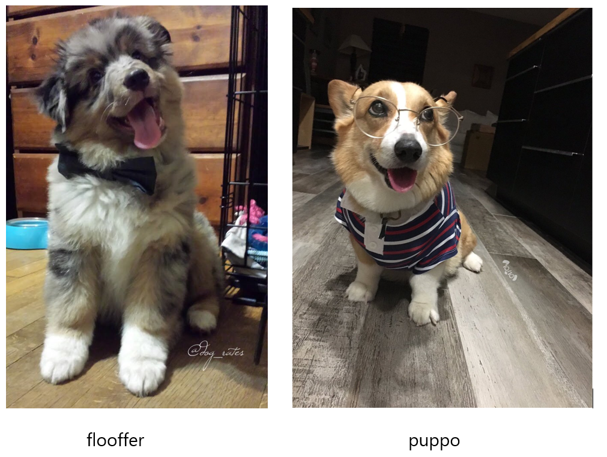

## In Conclusion:

> 1. Over 98% of the tweets sent by @WeRateDogs are sent through Twitter for iPhone. However, owing to the tools provided by the TweetDeck platform, tweets from there have minimum like count of 2010 (Way higher than the other sources).
> 2. Tweets made by @WeRateDogs in December, 2015 have the highest number of retweets while tweets made in July 2017 had the highest number of likes. July 2016 had the highest average dog ratings of the period considered. This seems interesing and would require further investigation.
> 3. From the analysis carried out, puppo and floofer are the most highly rated dog characteristics or traits.